Ficha del establecimiento

# Escuela Villa Sur

RBD **9729**Pedro Aguirre CerdaEscuela o liceo

223estudiantes matriculadosCorte Agosto 2026

Mujeres41,7%93 est.

Hombres58,3%130 est.

Chilenos/as75,8%169 est.

Extranjeros/as24,2%54 est.

Actualizada al 05-10-2026

💻Ver ficha completaVersión para computador, con mapas y gráficos interactivos. Pesa varios MB: mejor ábrela con wifi.

🏛️Identificación

## Identificación del establecimiento

Los datos de contacto y las características básicas del establecimiento, tal como están registrados en el Ministerio de Educación. **Si algo está mal o falta, escríbenos** y lo corregimos en la próxima actualización.

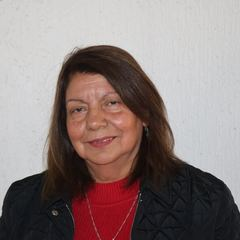

Director o directora

Raquel Elizabeth Ponce Ramirez

Seleccionado/a por Alta Direccion Publica

**Nombre**

Escuela Villa Sur

**RBD**

9729

**Dirección**

Los Molles 2973

**Comuna**

Pedro Aguirre Cerda

**Tipo**

Escuela o liceo

**Estado**

✅En funcionamiento

**Director/a**

Raquel Elizabeth Ponce Ramirez

**Correo**

escuelavillasur@slepsantarosa.cl

**Teléfono**

443144768

**Sitio web**

WWW.PEDROAGUIRRECERDA.CL

**Matrícula**

GRATUITO

**Sostenedor**

El sostenedor corresponde a una persona jurídica

**Orientación**

Orientación religiosa Laica

### Niveles que imparte

✓ 🧸 Educación Parvularia✓ 🎒 Enseñanza Básica Niños

### Vulnerabilidad del alumnado

Índice de vulnerabilidad (IVE)

95,6%

Lo calcula JUNAEB y sirve para asignar programas de apoyo.

0%100%

Este establecimientoPromedio de la comuna 85%

Prioritarios en Básica

92,9%

Estudiantes en 1ª, 2ª o 3ª prioridad.

**Un IVE más alto significa más necesidad de apoyo**, no peor calidad. Se usa para decidir a qué establecimientos llegan primero los programas de alimentación, salud y becas.

### Apoyos profesionales al aprendizaje

✓ 📚 Reforzamiento✓ 🧩 Psicopedagogo/a✓ 🧠 Psicólogo/a✓ 👩‍🏫 Profesor/a de educación especial✓ 🤝 Asistente social✓ 🗣️ Fonoaudiólogo/a🧭 Orientador/a🎓 Orientación vocacional➕ Otro

### Infraestructura y atención a la diversidad

✓ 📚 Biblioteca✓ 🏛️ Sala multiuso✓ 🌐 Computadores con internet✓ 🖥️ Sala de informática✓ 🏟️ Cancha deportiva✓ ➕ Otra: SALA DE MÚSICA🔬 Laboratorio💻 Computadores📽️ Sala audiovisual🤾 Gimnasio♿ Accesibilidad NEE

✓ 🧠 Discapacidad intelectual✓ 🦽 Discapacidad motora✓ 🧩 Trastorno del espectro autista✓ 📖 Dificultades de aprendizaje✓ 🗣️ Trastorno específico del lenguaje✓ 🎯 Déficit atencional👁️ Discapacidad visual👂 Discapacidad auditiva💬 Trastornos de la comunicación📊 Funcionamiento intelectual limítrofe

Las etiquetas con ✓ son las que el establecimiento declaró en el directorio oficial; las grises no están marcadas.

### Jornada Escolar Completa (JEC)

Cursos con jornada completa

0

Cursos sin jornada completa

10

**Ver curso por curso**

| Grado | Cursos | Jornada |
| --- | --- | --- |
| 1° Básico | 1 | — Sin JEC |
| 2° Básico | 1 | — Sin JEC |
| 3° Básico | 1 | — Sin JEC |
| 4° Básico | 1 | — Sin JEC |
| 5° Básico | 1 | — Sin JEC |
| 6° Básico | 1 | — Sin JEC |
| 7° Básico | 1 | — Sin JEC |
| 8° Básico | 1 | — Sin JEC |
| Kínder | 1 | — Sin JEC |
| Pre-kínder | 1 | — Sin JEC |

Con **Jornada Escolar Completa** los estudiantes tienen más horas de clases al día y almuerzan en el establecimiento.

### Idiomas

**Inglés en Enseñanza Básica**

Básico

**Inglés en Enseñanza Media**

Básico

### Certificación ambiental (SNCAE)

El establecimiento no tiene certificación del Sistema Nacional de Certificación Ambiental de Establecimientos Educacionales (SNCAE).

### Concentración de alumnado prioritario

Concentración 2026

61,6%

▼9,55 pts

Porcentaje de estudiantes prioritarios reconocidos por el Mineduc.

0%100%

Concentración del establecimiento

Concentración 2025

71,1%

Resolución exenta

2026

Observación del Ministerio: **Mantienen ACAP**.

La **concentración de prioritarios** define cuánta Subvención Escolar Preferencial (SEP) recibe el establecimiento. Sobre 60 % da acceso a la asignación por concentración.

### Requisitos para postular

✓ 🎂 Cumplir la edad mínima✓ 📄 Certificado de nacimiento✓ 📊 Certificado de notas✓ 📝 Informe de personalidad✓ ⚖️ Firmar el reglamento de convivencia🏠 Ficha de protección social🧪 Test de intereses♿ Informe de necesidades educativas✍️ Firmar el proyecto educativo📋 Examen de ingreso👥 Entrevista con apoderados🎲 Sorteo💍 Certificado de matrimonio⛪ Certificado de bautismo⛪ Certificado de matrimonio religioso💰 Pago de postulación➕ Otro

Desde el Sistema de Admisión Escolar, los establecimientos públicos **no pueden seleccionar** por rendimiento ni por antecedentes socioeconómicos. Estos son los antecedentes administrativos que el establecimiento declara pedir.

**Equipo del SLEP que acompaña al establecimiento**

**Asesor/a territorial**

DIEGO JARA ASQUET

**Correo UTP**

utp.escuelavillasur@slepsantarosa.cl

**Correo Inspectoría**

inspectoria.escuelavillasur@slepsantarosa.cl

🏫Matrícula

## Matrícula y asistencia

Cuántos estudiantes tiene el establecimiento, quiénes son y cuántos días van efectivamente a clases. **La asistencia es el porcentaje de días que los estudiantes asistieron** sobre los días en que estuvieron matriculados.

Matrícula · Agosto 2026

223

▲9,3%

Variación desde el primer mes del año escolar.

1141.024

Este establecimientoPromedio del SLEP 333

Asistencia promedio

83,8%

Días asistidos sobre días matriculados.

82,4%94,3%

Este añoPromedio de años anteriores 86,7%

Cursos

10

Niveles

2

Matrícula regular

223

Estudiantes en la modalidad regular del establecimiento.

Matrícula no regular

0

Modalidades de adultos, reingreso o validación de estudios.

Matrícula mes a mes · 2026

Cuántos estudiantes había registrados al cierre de cada mes.

Asistencia mes a mes · 2026

Porcentaje de días asistidos sobre los días en que el estudiante estuvo matriculado.

Matrícula año a año

Matrícula del último mes de cada año escolar.

### Quiénes estudian acá

Por género

Hombres · 130Mujeres · 93

Por origen

Chilenos/as · 169Extranjeros/as · 54Nacionalizados/as · 0

Nacionalidades presentes

Número de estudiantes por país de nacimiento declarado.

🇨🇱 Chilena167

🇻🇪 Venezolana20

🌐 Otra13

❔ Sin información8

🇭🇹 Haitiana6

🇨🇴 Colombiana2

Otros4

Pueblos originarios

Estudiantes que declaran pertenecer a un pueblo originario.

🌿 Mapuche6

🌐 Otra etnia3

### Por nivel de enseñanza

Matrícula por nivel

🧸 Educación Parvularia29

🎒 Enseñanza Básica Niños194

Asistencia por nivel

La escala va de 0 % a 100 %.

🧸 Educación Parvularia79,5%

🎒 Enseñanza Básica Niños84,4%

### Asistencia por grupo

Asistencia por género

Promedio ponderado por el número de estudiantes de cada grupo.

Hombres81,8%

Mujeres86,6%

Asistencia por origen

Chilenos/as82,2%

Extranjeros/as89,2%

Asistencia por nacionalidad

Solo los seis grupos con más estudiantes.

🇨🇱 Chilena82,6%

🇻🇪 Venezolana88,3%

🌐 Otra89,4%

❔ Sin información73,8%

🇭🇹 Haitiana96,8%

🇨🇴 Colombiana96,9%

Asistencia por pueblo originario

🌿 Mapuche55,6%

🌐 Otra etnia0,0%

**Ver el detalle curso por curso (10 cursos)**

| Curso | Matrícula | Asistencia % |
| --- | --- | --- |
| Pre-kínder A | 18 | 80,1 |
| Kínder A | 11 | 78,6 |
| 1° Básico A | 15 | 75,2 |
| 2° Básico A | 14 | 91,5 |
| 3° Básico A | 15 | 76,2 |
| 4° Básico A | 32 | 88,1 |
| 5° Básico A | 29 | 82,5 |
| 6° Básico A | 35 | 85,2 |
| 7° Básico A | 25 | 84,5 |
| 8° Básico A | 29 | 87 |

**Ver la matrícula año a año, con su variación**

| Periodo | Matrícula | Variación | Cambio |
| --- | --- | --- | --- |
| 2026 | 223 | +3,0 | +1,4% |
| 2025 | 220 | −18,0 | −7,6% |
| 2024 | 238 | +3,0 | +1,3% |
| 2023 | 235 | −8,0 | −3,3% |
| 2022 | 243 | −50,0 | −17,1% |
| 2019 | 293 | +6,0 | +2,1% |
| 2018 | 287 | +32,0 | +12,5% |
| 2017 | 255 | +44,0 | +20,9% |
| 2016 | 211 | — | — |

**Ver la asistencia año a año, con su variación**

| Periodo | Asistencia | Variación | Cambio |
| --- | --- | --- | --- |
| 2026 | 83,8% | −2,5 pts | −2,9% |
| 2025 | 86,3% | +2,3 pts | +2,7% |
| 2024 | 84,0% | +0,8 pts | +1,0% |
| 2023 | 83,2% | −7,6 pts | −8,4% |
| 2022 | 90,8% | +7,1 pts | +8,5% |
| 2019 | 83,7% | −3,8 pts | −4,3% |
| 2018 | 87,5% | +3,1 pts | +3,7% |
| 2017 | 84,4% | −9,1 pts | −9,7% |
| 2016 | 93,5% | — | — |

La matrícula se cuenta al cierre de cada mes, así que los cambios durante el año reflejan traslados y retiros. Corte usado: **Agosto 2026**.

🤝Vida escolar

## Vida escolar y comunidad

Qué actividades ofrece el establecimiento fuera de las clases, cómo se organiza con las familias y quiénes representan a la comunidad. **Las etiquetas con ✓ son las que el establecimiento declaró** en el directorio oficial del Ministerio; las grises no están marcadas.

### Talleres y actividades para estudiantes

✓ 🤝 Convivencia✓ 🚫 Prevención drogas✓ ❤️ Educación sexual✓ 🌱 Medio ambiente✓ 🌟 Vida sana🧭 Orientación🫂 Acción social✝️ Pastoral➕ Otra

Actividades de formación: orientación, convivencia, prevención y vida sana.

✓ 🎵 Música✓ 🎨 Artes plásticas✓ 💻 Taller TIC🎭 Teatro📚 Literatura✂️ Manualidades🩰 Danza o ballet🎓 Preuniversitario➕ Otro

Talleres de arte, cultura y tecnología fuera del horario de clases.

✓ ⚽ Fútbol✓ 🥅 Baby fútbol✓ 🏀 Básquetbol✓ 🤸 Gimnasia✓ 🏓 Tenis de mesa✓ ♟️ Ajedrez🏃 Atletismo🏐 Vóleibol🏊 Natación🎾 Tenis➕ Otro

Disciplinas deportivas que ofrece el establecimiento.

### Trabajo con las familias

✓ 👪 Talleres de formación✓ 🎉 Actividades de integración✓ 📈 Perfeccionamiento➕ Otra

✓ 📒 Libreta de comunicaciones✓ 🗣️ Consejo escolar✓ 📄 Reuniones generales✓ 👥 Entrevistas individuales🌐 Web y redes sociales➕ Otro

Por dónde el establecimiento se comunica con apoderados y apoderadas.

### Organizaciones de la comunidad

**Centro de Padres**

Constituido

**Personalidad jurídica**

Vigente

**Última elección de directiva**

**Centro de Estudiantes**

Constituido

**Representante del sostenedor en el Consejo Escolar**

Eiden Viera Pardo

**Acompañamiento del Consejo Escolar**

Eiden Viera Pardo

Para contactar al centro de padres o al centro de estudiantes, escribe al establecimiento: sus datos están más arriba.

El **Consejo Escolar** es la instancia donde se juntan dirección, docentes, asistentes, apoderados y estudiantes para conversar sobre la marcha del establecimiento.

### Normativa y conectividad

**Uso de uniforme**

Uniforme regular

**Tipo de conexión**

Fibra óptica

**Velocidad de internet**

Sin información

🧭Gestión

## Instrumentos de gestión: PEI y PME

El **PEI** dice quién quiere ser el establecimiento: su misión, su visión y sus sellos. El **PME** dice qué va a hacer este año para lograrlo, con responsables y presupuesto. Son los dos documentos que ordenan el trabajo.

### Proyecto Educativo Institucional (PEI)

**Misión**

Somos una institución educativa comprometida en educar a niños y niñas para la adquisición de un claro dominio en las distintas áreas del conocimiento y el desarrollo de competencias deportivas y artísticas que les permitan adquirir habilidades sociales para continuar óptimamente su formación escolar en la enseñanza media.

**Visión**

Escuela de Educación Prebásica y Básica, abierta e inclusiva, que forma integralmente a las personas en los valores esenciales de respeto, responsabilidad y compromiso consigo mismo y su entorno biopsicosocial con actitud positiva y autonomía en todos los aspectos de la vida.

### Énfasis declarados, en orden de prioridad

**1º**

Excelencia académica

**2º**

Desarrollo integral

**3º**

Inclusivo

### Documentos oficiales

[📘Proyecto Educativo](https://wwwfs.mineduc.cl/Archivos/infoescuelas/documentos/9729/ProyectoEducativo9729.pdf)[⚖️Reglamento de Convivencia](https://wwwfs.mineduc.cl/Archivos/infoescuelas/documentos/9729/ReglamentodeConvivencia9729.pdf)[📊Reglamento de Evaluación](https://wwwfs.mineduc.cl/Archivos/infoescuelas/documentos/9729/ReglamentoDeEvaluacion9729.pdf)

### Plan de Mejoramiento Educativo (PME)

Acciones comprometidas

18

Inversión total del plan

$ 121.668.313

Dimensiones cubiertas

4

Acciones por dimensión

Las cuatro dimensiones del PME: gestión pedagógica, liderazgo, convivencia y recursos.

Gestión Pedagógica7

Gestión de Recursos4

Liderazgo4

Convivencia Escolar3

Quién lidera las acciones

Los cinco responsables con más acciones a cargo.

Equipo de gestión4

Director3

Docente3

Encargado de convivencia3

Jefe técnico2

De dónde sale el financiamiento

Monto comprometido por fuente de recursos.

sep$ 119.357.628

pie$ 2.310.685

**Ver las 18 acciones del plan**

| Acción | Dimensión | Responsable | Monto |
| --- | --- | --- | --- |
| MEJORAMIENTO DE ESPACIOS EDUCATIVOS | Gestión Pedagógica | Docente | $ 1.674.802 |
| SALIDAS PEDAGÓGICAS | Gestión Pedagógica | Equipo de gestión | $ 2.310.685 |
| LECTURA Y ESCRITURA DIGITAL | Gestión Pedagógica | Equipo de gestión | $ 207.365 |
| TALLERES FORMATIVOS. | Gestión Pedagógica | Docente | $ 2.200.000 |
| PLAN DE TRANSICIÓN EDUCACIONAL. | Gestión Pedagógica | Docente | $ 500.000 |
| BIBLIOTECA CRA | Gestión Pedagógica | Coordinadora CRA | $ 2.041.598 |
| SERVICIO DE PLATAFORMA EDUCATIVA. | Gestión Pedagógica | Jefe técnico | $ 1.532.929 |
| MONITOREO PME | Liderazgo | Equipo de gestión | $ 200.000 |
| INTERNALIZACIÓN Y DIFUSIÓN DEL PEI | Liderazgo | Equipo de gestión | $ 0 |
| ACOMPAÑAMIENTO TÉCNICO PEDAGÓGICO | Liderazgo | Jefe técnico | $ 250.000 |
| CONTRATACIÓN DE PROFESIONALES PARA FORTALECER LA GESTIÓN DE SOPORTE PARA LOS PROCESOS EDUCATIVOS. | Liderazgo | Sostenedor | $ 9.080.736 |
| MONITOREO Y SEGUIMIENTO AL PLAN DE CONVIVENCIA ESCOLAR. | Convivencia Escolar | Encargado de convivencia | $ 0 |
| PARTICIPACIÓN DE LOS PADRES Y APODERADOS. | Convivencia Escolar | Encargado de convivencia | $ 200.000 |
| MONITOREO Y SEGUIMIENTO A LA ASISTENCIA. | Convivencia Escolar | Encargado de convivencia | $ 718.407 |
| ADQUISICIÓN DE RECURSOS TICS, MODIFICACION O ADECUACIÓN DE ESPACIOS EDUCATIVOS. | Gestión de Recursos | Coordinador Enlace | $ 1.719.808 |
| PERSONAL DE APOYO A LA GESTIÓN. | Gestión de Recursos | Director | $ 95.347.728 |
| SERVICIO DE EQUIPO MULTICOPIADORES PARA EL APOYO PEDAGÓGICO. | Gestión de Recursos | Director | $ 2.417.989 |
| ADQUISICIÓN DE MATERIAL ESCOLAR PARA EL APOYO AL APRENDIZAJE | Gestión de Recursos | Director | $ 1.266.266 |

**Ver plazos y estado de ejecución de cada acción**

| Acción | Inicio | Término | Nivel de ejecución |
| --- | --- | --- | --- |
| MEJORAMIENTO DE ESPACIOS EDUCATIVOS | 05/3/2025 | 28/11/2025 | Implementado (100%) |
| SALIDAS PEDAGÓGICAS | 05/3/2025 | 28/11/2025 | Implementado (100%) |
| LECTURA Y ESCRITURA DIGITAL | 05/3/2025 | 30/11/2025 | Implementado inicialmente (1% a 24%) |
| TALLERES FORMATIVOS. | 06/3/2025 | 28/11/2025 | Implementado (100%) |
| PLAN DE TRANSICIÓN EDUCACIONAL. | 06/3/2025 | 29/11/2025 | Implementado (100%) |
| BIBLIOTECA CRA | 06/3/2025 | 01/12/2025 | Implementado (100%) |
| SERVICIO DE PLATAFORMA EDUCATIVA. | 05/3/2025 | 05/12/2025 | Implementado (100%) |
| MONITOREO PME | 06/3/2025 | 29/11/2025 | Implementado (100%) |
| INTERNALIZACIÓN Y DIFUSIÓN DEL PEI | 05/3/2025 | 28/11/2025 | No Implementado (0%) |
| ACOMPAÑAMIENTO TÉCNICO PEDAGÓGICO | 05/3/2025 | 28/11/2025 | Implementado (100%) |
| CONTRATACIÓN DE PROFESIONALES PARA FORTALECER LA GESTIÓN DE SOPORTE PARA LOS PROCESOS EDUCATIVOS. | 05/3/2025 | 05/12/2025 | Implementado (100%) |
| MONITOREO Y SEGUIMIENTO AL PLAN DE CONVIVENCIA ESCOLAR. | 05/3/2025 | 28/11/2025 | No Implementado (0%) |
| PARTICIPACIÓN DE LOS PADRES Y APODERADOS. | 05/3/2025 | 28/11/2025 | Implementado (100%) |
| MONITOREO Y SEGUIMIENTO A LA ASISTENCIA. | 05/3/2025 | 28/11/2025 | Implementado (100%) |
| ADQUISICIÓN DE RECURSOS TICS, MODIFICACION O ADECUACIÓN DE ESPACIOS EDUCATIVOS. | 06/3/2025 | 30/11/2025 | Implementado (100%) |
| PERSONAL DE APOYO A LA GESTIÓN. | 06/3/2025 | 01/12/2025 | Implementado (100%) |
| SERVICIO DE EQUIPO MULTICOPIADORES PARA EL APOYO PEDAGÓGICO. | 06/3/2025 | 07/12/2025 | Implementado (100%) |
| ADQUISICIÓN DE MATERIAL ESCOLAR PARA EL APOYO AL APRENDIZAJE | 05/3/2025 | 30/11/2025 | Implementado (100%) |

**Ver estrategia, programa y medios de verificación**

| Acción | Estrategia | Programa asociado | Medios de verificación |
| --- | --- | --- | --- |
| MEJORAMIENTO DE ESPACIOS EDUCATIVOS | Consolidar las estrategias que nos permita apoyar a tiempo a las y los estudiantes que presentan dificultades académicas y sociales, de acuerdo a sus intereses diversos y habilidades destacadas. | SEP | -- Informe de impacto -- Registro de uso de sala sensorial y psicomotricidad. |
| SALIDAS PEDAGÓGICAS | Consolidar las estrategias que nos permita apoyar a tiempo a las y los estudiantes que presentan dificultades académicas y sociales, de acuerdo a sus intereses diversos y habilidades destacadas. | SEP | -Informe de impacto de las salidas pedagógicas en los aprendizajes. -Planificación y guía de trabajo. -Informe de salidas pedagógicas |
| LECTURA Y ESCRITURA DIGITAL | Consolidar las estrategias que nos permita apoyar a tiempo a las y los estudiantes que presentan dificultades académicas y sociales, de acuerdo a sus intereses diversos y habilidades destacadas. | SEP | -Informe uso de plataforma. -Informe de impacto de la acción. |
| TALLERES FORMATIVOS. | Consolidar las estrategias que nos permita apoyar a tiempo a las y los estudiantes que presentan dificultades académicas y sociales, de acuerdo a sus intereses diversos y habilidades destacadas. | SEP | -Planificaciones mensuales. -Informe de actividades y evaluación semestral de los talleres. |
| PLAN DE TRANSICIÓN EDUCACIONAL. | Consolidar las estrategias que nos permita apoyar a tiempo a las y los estudiantes que presentan dificultades académicas y sociales, de acuerdo a sus intereses diversos y habilidades destacadas. | SEP | -cronograma, registro de reuniones entre niveles e informe de seguimiento a los acuerdos tomados -Proyecto de articulación. -Informe de impacto de la acción. |
| BIBLIOTECA CRA | Consolidar las estrategias que nos permita apoyar a tiempo a las y los estudiantes que presentan dificultades académicas y sociales, de acuerdo a sus intereses diversos y habilidades destacadas. | CRA | -Plan de acción CRA. -Registro de visita al CRA y uso de material didáctico y educativo. -Plan lector por curso e Informe de impacto del plan lector. |
| SERVICIO DE PLATAFORMA EDUCATIVA. | Consolidar las estrategias que nos permita apoyar a tiempo a las y los estudiantes que presentan dificultades académicas y sociales, de acuerdo a sus intereses diversos y habilidades destacadas. | SEP | -Registro de pago mensual de plataforma -Registro de asistencia a capacitaciones -Informe de progreso de la acción |
| MONITOREO PME | Fortalecimiento de los lineamientos del PEI, acompañamiento y monitoreo de la gestión institucional para la toma oportuna de decisiones con todos los estamentos de la comunidad educativa. | SEP | -Material expositivo respecto al estado de avance del PME -Informe de impacto de las acciones implementadas del PME en el proceso de aprendizaje. -Matriz de monitoreo de las acciones del PME. |
| INTERNALIZACIÓN Y DIFUSIÓN DEL PEI | Fortalecimiento de los lineamientos del PEI, acompañamiento y monitoreo de la gestión institucional para la toma oportuna de decisiones con todos los estamentos de la comunidad educativa. | SEP | -Informe de análisis de la encuesta sobre el conocimiento del PEI. -Encuesta de conocimiento del PEI. -Material pedagógico utilizado en capacitación para la difusión del PEI en la Comunidad Escolar. |
| ACOMPAÑAMIENTO TÉCNICO PEDAGÓGICO | Fortalecimiento de los lineamientos del PEI, acompañamiento y monitoreo de la gestión institucional para la toma oportuna de decisiones con todos los estamentos de la comunidad educativa. | SEP | -cronograma de reuniones por ciclo, actas de reuniones e informe de seguimiento a los acuerdos tomado -Informe de impacto del análisis de resultados. |
| CONTRATACIÓN DE PROFESIONALES PARA FORTALECER LA GESTIÓN DE SOPORTE PARA LOS PROCESOS EDUCATIVOS. | Fortalecimiento de los lineamientos del PEI, acompañamiento y monitoreo de la gestión institucional para la toma oportuna de decisiones con todos los estamentos de la comunidad educativa. | SEP | -Informe de avance y ejecución. -Convenios de prestación de servicios |
| MONITOREO Y SEGUIMIENTO AL PLAN DE CONVIVENCIA ESCOLAR. | Desarrollar proceso formativo con todos los integrantes de la comunidad escolar a través de acciones que contribuyan a la participación activa, promoviendo un ambiente caracterizado por el respeto y e… | SEP | -Informe de impacto del plan de convivencia escolar en el mejoramiento del clima escolar. -Plantilla de seguimiento y monitoreo de las acciones del plan de convivencia escolar. |
| PARTICIPACIÓN DE LOS PADRES Y APODERADOS. | Desarrollar proceso formativo con todos los integrantes de la comunidad escolar a través de acciones que contribuyan a la participación activa, promoviendo un ambiente caracterizado por el respeto y e… | SEP | -cronograma de actividades, actas de reuniones e informe de seguimiento a los acuerdos tomados -Informe de evolución del impacto de la acción. -Plan de gestión de la convivencia escolar. |
| MONITOREO Y SEGUIMIENTO A LA ASISTENCIA. | Desarrollar proceso formativo con todos los integrantes de la comunidad escolar a través de acciones que contribuyan a la participación activa, promoviendo un ambiente caracterizado por el respeto y e… | SEP | -Informe del impacto de acción. -Informe mensual del monitoreo a la asistencia. -Plan de acompañamiento social. |
| ADQUISICIÓN DE RECURSOS TICS, MODIFICACION O ADECUACIÓN DE ESPACIOS EDUCATIVOS. | Gestionar la compra, renovación y monitoreo del uso de los recursos tecnológicos y didácticos, que vayan en directo beneficio de los aprendizajes de las y los estudiantes. | SEP | -Informe de evaluación del impacto de la acción. -Planilla de uso de los recursos tecnológicos. -Plan de acción Enlaces. |
| PERSONAL DE APOYO A LA GESTIÓN. | Gestionar la compra, renovación y monitoreo del uso de los recursos tecnológicos y didácticos, que vayan en directo beneficio de los aprendizajes de las y los estudiantes. | SEP | -Informe semestral de las acciones realizadas por el personal de apoyo. |
| SERVICIO DE EQUIPO MULTICOPIADORES PARA EL APOYO PEDAGÓGICO. | Gestionar la compra, renovación y monitoreo del uso de los recursos tecnológicos y didácticos, que vayan en directo beneficio de los aprendizajes de las y los estudiantes. | SEP | -Registro de material impreso. -Contrato suministro -Informe de impresiones mensuales |
| ADQUISICIÓN DE MATERIAL ESCOLAR PARA EL APOYO AL APRENDIZAJE | Gestionar la compra, renovación y monitoreo del uso de los recursos tecnológicos y didácticos, que vayan en directo beneficio de los aprendizajes de las y los estudiantes. | SEP | -Facturas. -Proceso de compras públicas. |

**Ver la descripción completa y la justificación de cada acción**

| Acción | Qué se hace | Por qué |
| --- | --- | --- |
| MEJORAMIENTO DE ESPACIOS EDUCATIVOS | Mejorar las condiciones de la sala sensorial y psicomotricidad, para lograr un desarrollo integral de los niños y niñas de prekinder a 8°, adquiriendo habilidades motoras, cognitivas y afectivas. | El nivel de implementación está dentro del curso adecuado en relación a las fechas programadas. |
| SALIDAS PEDAGÓGICAS | Desarrollar 1 salidas pedagógicas al año (museos, exposiciones, ferias, entre otros) para generar aprendizajes significativos y enriquecer el desarrollo cultural de las y los estudiantes desde prebási… | El nivel de implementación está dentro del curso adecuado en relación a las fechas programadas. |
| LECTURA Y ESCRITURA DIGITAL | Desarrollar habilidades de lectura y escritura en estudiantes de 1° y 2° básico a través de programas informáticos de lenguaje donde se trabaje en actividades interactivas y lúdicas 1 vez por semana | El nivel de implementación está dentro del curso adecuado en relación a las fechas programadas. |
| TALLERES FORMATIVOS. | Realización de talleres extra programáticos 1 vez por semana, para el desarrollo de habilidades y talentos en los estudiantes, fortaleciendo sus aprendizajes transversales. Taller de inglés NT1 a 4º b… | El nivel de implementación está dentro del curso adecuado en relación a las fechas programadas. |
| PLAN DE TRANSICIÓN EDUCACIONAL. | Favorecer instancias de articulación pedagógica entre los niveles de educación parvularia y 1° año básico, mediante el diseño y desarrollo de experiencias de aprendizaje compartidas, orientadas al for… | El nivel de implementación está dentro del curso adecuado en relación a las fechas programadas. |
| BIBLIOTECA CRA | Fomentar el gusto por la lectura a través de la implementación de un plan lector dirigido a estudiantes de NT1 a 8° básico. Adquisición de material escolar e insumos de material pedagógico para dar us… | El nivel de implementación está dentro del curso adecuado en relación a las fechas programadas. |
| SERVICIO DE PLATAFORMA EDUCATIVA. | La plataforma educativa es una herramienta digital que facilita la planificación, implementación y seguimiento con un enfoque pedagógico. Su propósito es fortalecer la gestión curricular y didáctica, … | El nivel de implementación está dentro del curso adecuado en relación a las fechas programadas. |
| MONITOREO PME | Realizar monitoreo y seguimiento dos veces por semestre al Plan de Mejoramiento Educativo por el Equipo de Gestión, a través de formatos que muestre el avance en la implementación de las acciones plan… | El nivel de implementación está dentro del curso adecuado en relación a las fechas programadas. |
| INTERNALIZACIÓN Y DIFUSIÓN DEL PEI | Internalizar y difundir el Proyecto educativo Institucional con toda la Comunidad Educativa a través de reuniones con los diferentes estamentos enfocadas en fortalecer los valores y principios institu… | La asignación de los recursos fue interrumpida. |
| ACOMPAÑAMIENTO TÉCNICO PEDAGÓGICO | Coordinar con las y los docentes del primer y segundo ciclo el seguimiento y análisis de resultados del trabajo pedagógico del establecimiento, para poder tomar medidas de mejora de manera sistemática… | El nivel de implementación está dentro del curso adecuado en relación a las fechas programadas. |
| CONTRATACIÓN DE PROFESIONALES PARA FORTALECER LA GESTIÓN DE SOPORTE PARA LOS PROCESOS EDUCATIVOS. | Contratación de profesionales especializados en distintas áreas para fortalecer la gestión de los procesos educativos en los establecimientos educacionales, optimizando la planificación, seguimiento y… | El nivel de implementación está dentro del curso adecuado en relación a las fechas programadas. |
| MONITOREO Y SEGUIMIENTO AL PLAN DE CONVIVENCIA ESCOLAR. | Realizar seguimiento y monitoreo al Plan de convivencia escolar, el cual nos permita tomar decisiones de manera efectiva y oportuna respecto al acompañamiento social y derivaciones a redes de apoyo a … | La asignación de los recursos fue interrumpida. |
| PARTICIPACIÓN DE LOS PADRES Y APODERADOS. | Desarrollar talleres formativos para padres, proporcionando información, orientación, formación y asesoramiento al Centro general de Padres y subcentros, por el importante rol que cumplen, propiciando… | El nivel de implementación está dentro del curso adecuado en relación a las fechas programadas. |
| MONITOREO Y SEGUIMIENTO A LA ASISTENCIA. | Seguimiento a las y los estudiantes desde NT1 a octavo básico, que presenten ausencias reiteradas a través de llamados, entrevistas a los apoderados, así como monitoreo a estudiantes derivados a redes… | El nivel de implementación está dentro del curso adecuado en relación a las fechas programadas. |
| ADQUISICIÓN DE RECURSOS TICS, MODIFICACION O ADECUACIÓN DE ESPACIOS EDUCATIVOS. | Adquisición y utilización de Recursos tecnológicos desde NT1 a 8°básico en las diferentes asignaturas según planificación, para el Mejoramiento de las habilidades tecnológicas de los estudiantes y de … | El nivel de implementación está dentro del curso adecuado en relación a las fechas programadas. |
| PERSONAL DE APOYO A LA GESTIÓN. | Contar con personal de apoyo a la gestión que vaya en directo beneficio de mejorar los aprendizajes y convivencia de los estudiantes, prestando todo el apoyo pedagógico y social a quienes lo requieran… | El nivel de implementación está dentro del curso adecuado en relación a las fechas programadas. |
| SERVICIO DE EQUIPO MULTICOPIADORES PARA EL APOYO PEDAGÓGICO. | Contratación de un servicio de multicopiado para la impresión de material didáctico de calidad, con el objetivo de fortalecer los procesos de enseñanza y aprendizaje de los estudiantes. | El nivel de implementación está dentro del curso adecuado en relación a las fechas programadas. |
| ADQUISICIÓN DE MATERIAL ESCOLAR PARA EL APOYO AL APRENDIZAJE | Adquisición de material escolar e insumos de material pedagógico para garantizar que todos los estudiantes cuenten con los recursos necesarios para su desarrollo académico, fortaleciendo el acceso equ… | El nivel de implementación está dentro del curso adecuado en relación a las fechas programadas. |

🏆SNED

## SNED · Sistema Nacional de Evaluación del Desempeño

El SNED evalúa cada dos años el desempeño de los establecimientos municipales y particulares subvencionados. Mira **seis factores**: efectividad, superación, igualdad de oportunidades, iniciativa, integración y mejoramiento.

⚪No seleccionado

Índice SNED del establecimiento

Va de 0 a 100 y resume los seis factores que evalúa el sistema.

Los seis factores, uno por uno

Cada factor va de 0 a 100. Los de arriba pesan más en el índice final.

Efectividad47,2%

Superación55,2%

Igualdad de oportunidades93,9%

Iniciativa89,9%

Integración67,4%

Mejoramiento99,0%

**¿Cuánto pesa cada factor?**

| Factor | Puntaje | Peso en el índice (%) |
| --- | --- | --- |
| Efectividad | 47,2 | 37 |
| Superación | 55,2 | 28 |
| Igualdad de oportunidades | 93,9 | 22 |
| Iniciativa | 89,9 | 6 |
| Integración | 67,4 | 5 |
| Mejoramiento | 99 | 2 |

El SNED premia con un bono a los equipos de los establecimientos con mejor desempeño dentro de un grupo de escuelas parecidas. **No es una nota**: compara con establecimientos de condiciones similares, no con todo Chile.

💼Ocupación

## Ocupación de cupos

Cuántos de los cupos que el establecimiento ofreció están efectivamente ocupados. **Se calcula dividiendo la matrícula actual por los cupos declarados** en el Sistema de Admisión Escolar (SAE).

🚨Con muchos cupos disponibles

Ocupación de los cupos

La marca gris señala el 100 %: por sobre esa línea hay más estudiantes que cupos declarados.

Cupos declarados (SAE)

Matrícula al corte

223

Agosto 2026

Cupos libres

Cupos que quedan sin usar.

Vacantes en el curso de ingreso

20

**Ver los cupos declarados por grado**

| Grado | Cursos | Cupos |
| --- | --- | --- |
| 1° Básico | 1 | 35 |
| 2° Básico | 1 | 35 |
| 3° Básico | 1 | 35 |
| 4° Básico | 1 | 35 |
| 5° Básico | 1 | 35 |
| 6° Básico | 1 | 35 |
| 7° Básico | 1 | 35 |
| 8° Básico | 1 | 35 |
| Kínder | 1 | 30 |
| Pre-kínder | 1 | 20 |

La ocupación compara la **matrícula efectiva** con los **cupos que el establecimiento declaró** en el Sistema de Admisión Escolar. Una ocupación baja no siempre es mala: puede ser espacio para crecer.

♿PIE

## Programa de Integración Escolar (PIE)

Cuántos estudiantes reciben apoyos del PIE y qué tipo de apoyo necesitan. Las **necesidades permanentes** acompañan toda la trayectoria escolar; las **transitorias** requieren apoyo por un tiempo determinado.

Estudiantes en PIE · 2026

47

Se cuenta cada estudiante una sola vez.

0,0%40,0%

Porcentaje de la matrícula

NEE permanentes

10

Acompañan toda la trayectoria escolar.

NEE transitorias

37

Requieren apoyo por un tiempo acotado.

Sobre la matrícula

21,1%

Tipo de necesidad educativa

NEE permanentes · 10NEE transitorias · 37

Por género

Hombres · 29Mujeres · 18

Diagnósticos más frecuentes

Los ocho diagnósticos con más estudiantes.

Trastorno del Lenguaje18

Dificultades Específicas del Aprendizaje12

Discapacidad Intelectual8

Funcionamiento Intelectual Limítrofe4

Trastorno de Déficit Atencional3

Trastorno del Espectro Autista2

En qué cursos están

4° Básico7

6° Básico7

1° Básico5

2° Básico5

3° Básico5

7° Básico5

8° Básico5

5° Básico4

Kínder4

Por nivel de enseñanza

Enseñanza Básica Niños43

Educación Parvularia4

**Ver el cruce entre género y tipo de necesidad**

| Genero | PERMANENTE | TRANSITORIO |
| --- | --- | --- |
| Femenino | 3 | 15 |
| Masculino | 7 | 22 |

**Ver el cruce entre género y los diagnósticos más frecuentes**

| Genero | Dificultades Específicas del Aprendizaje | Discapacidad Intelectual | Trastorno del Lenguaje | Funcionamiento Intelectual Limítrofe | Trastorno de Déficit Atencional |
| --- | --- | --- | --- | --- | --- |
| Femenino | 5 | 3 | 10 | 0 | 0 |
| Masculino | 7 | 5 | 8 | 4 | 3 |

**Ver todos los diagnósticos registrados**

| Diagnóstico | Tipo de NEE | Estudiantes |
| --- | --- | --- |
| Trastorno del Lenguaje | TRANSITORIO | 18 |
| Dificultades Específicas del Aprendizaje | TRANSITORIO | 12 |
| Discapacidad Intelectual | PERMANENTE | 8 |
| Funcionamiento Intelectual Limítrofe | TRANSITORIO | 4 |
| Trastorno de Déficit Atencional | TRANSITORIO | 3 |
| Trastorno del Espectro Autista | PERMANENTE | 2 |

### Postulaciones al programa, por período

Estudiantes por año y período

El período **Regular** es la postulación anual; **Extraordinario** y **Excepcionalidad** son cupos que se abren después.

2026 · Excepcionalidad5

2026 · Regular63

2025 · Excepcionalidad4

2025 · Regular61

2024 · Regular + Excepcionalidad66

**Ver el detalle por año, período y tipo de necesidad**

| Año | Período | Tipo de NEE | Estudiantes |
| --- | --- | --- | --- |
| 2.026 | Excepcionalidad | PERMANENTE | 5 |
| 2.026 | Regular | PERMANENTE | 16 |
| 2.026 | Regular | TRANSITORIO | 47 |
| 2.025 | Excepcionalidad | PERMANENTE | 4 |
| 2.025 | Regular | PERMANENTE | 14 |
| 2.025 | Regular | TRANSITORIO | 47 |
| 2.024 | Regular + Excepcionalidad | PERMANENTE | 17 |
| 2.024 | Regular + Excepcionalidad | TRANSITORIO | 49 |

Evolución del programa

Fuente: base territorial del Área de Inclusión Educativa del SLEP.

El PIE entrega apoyos dentro del aula a estudiantes con necesidades educativas especiales. **Estar en PIE no es un diagnóstico permanente**: muchas necesidades son transitorias y se superan con apoyo.

🔄Retiros

## Retiros y movilidad estudiantil

Cuántos estudiantes se retiraron del establecimiento, cuándo y hacia dónde. **Lo importante es saber si volvieron a matricularse en otra parte**: quienes no lo hicieron son los casos que hay que buscar.

Retiros en 2026

14

Equivale al 6,3% de la matrícula actual.

Ya están en otro establecimiento

8

Se confirmó matrícula posterior.

Sin matrícula vigente

Requieren seguimiento: pueden estar fuera del sistema.

Pendiente en SIGE

6

Todavía sin información de destino.

En qué meses se producen

Tipo de movimiento

Cambio a otro EE fuera del SLEP12

Cambio a otro EE pertenenciente al SLEP1

Sin matrícula1

A qué establecimientos se van

Los seis destinos más frecuentes.

Colegio Lo Espejo3

Esc. De Parvulos Part. La Farola2

Colegio Cordillera De Los Andes1

Colegio Particular Padre Fidel Abarca1

Complejo Educ.part.monsenor Luis A.perez1

Escuela Particular Amigos1

Desde qué cursos

8° Básico4

2° Básico2

5° Básico2

6° Básico2

Kínder2

7° Básico1

Pre-kínder1

Qué tipo de establecimiento eligieron

Dependencia del establecimiento de destino.

Particular Subvencionado9

Otro Slep3

Mismo Slep1

Sin Matrícula1

A qué comunas se fueron

Pedro Aguirre Cerda4

El Bosque3

Lo Espejo3

La Pintana1

Melipilla1

San Bernardo1

Sin información1

**Ver todos los destinos, uno por uno**

| Establecimiento | Comuna | Dependencia | Estudiantes |
| --- | --- | --- | --- |
| Colegio Lo Espejo | Lo Espejo | Particular Subvencionado | 3 |
| Esc. De Parvulos Part. La Farola | El Bosque | Particular Subvencionado | 2 |
| Colegio Cordillera De Los Andes | San Bernardo | Otro Slep | 1 |
| Colegio Particular Padre Fidel Abarca | Pedro Aguirre Cerda | Particular Subvencionado | 1 |
| Complejo Educ.part.monsenor Luis A.perez | Pedro Aguirre Cerda | Particular Subvencionado | 1 |
| Escuela Particular Amigos | Pedro Aguirre Cerda | Particular Subvencionado | 1 |
| Escuela Particular El Bosque | El Bosque | Particular Subvencionado | 1 |
| Liceo Los Jazmines | Melipilla | Otro Slep | 1 |
| Liceo Municipal Enrique Backausse | Pedro Aguirre Cerda | Mismo Slep | 1 |
| Liceo N523 | La Pintana | Otro Slep | 1 |
| Sin destino informado | — | Sin Matrícula | 1 |

Un retiro no siempre es una pérdida: muchas veces la familia se cambia de comuna. Lo que sí requiere seguimiento son los estudiantes **sin matrícula vigente** en ningún otro establecimiento.

📚Resultados

## Resultados educativos

Cómo les fue a los estudiantes en sus notas y cuántos pasaron de curso. El **promedio general** va de 1,0 a 7,0 y la **tasa de aprobación** es el porcentaje de estudiantes que fue promovido al curso siguiente.

Promedio general · 2025

5,8de 7,0

Promedio de todas las notas finales, ponderado por el tamaño de cada curso.

5,46,3

Este establecimientoPromedio del SLEP 5,9

Tasa de aprobación

96,0%

Promovidos sobre el total de estudiantes con situación final.

50%100%

Este establecimientoPromedio del SLEP 97%

Estudiantes promovidos

191

Estudiantes reprobados

8

Cómo terminó el año 2025

Situación final de cada estudiante al cierre del año escolar.

Promovidos · 191Reprobados · 8Retirados · 8Trasladados · 34

Promedio general año a año

Escala de notas de 1,0 a 7,0.

Tasa de aprobación año a año

Porcentaje de estudiantes promovidos.

**Ver el detalle por curso (8 grados)**

| Grado | Estudiantes | Promedio | Aprobación % |
| --- | --- | --- | --- |
| 1° Básico | 24 | 5,7 | 92,3 |
| 2° Básico | 16 | 6,4 | 100 |
| 3° Básico | 31 | 5,9 | 92,6 |
| 4° Básico | 30 | 5,8 | 100 |
| 5° Básico | 39 | 5,6 | 94,1 |
| 6° Básico | 28 | 5,8 | 90,5 |
| 7° Básico | 36 | 5,6 | 96,8 |
| 8° Básico | 37 | 5,8 | 100 |

### Aprobación por grupo

Tasa de aprobación por género

Masculino93,5%

Femenino100,0%

Tasa de aprobación por origen

Chileno95,4%

Extranjero97,8%

**Ver el promedio de notas por grupo**

| Género | Estudiantes | Promedio | Aprobación % |
| --- | --- | --- | --- |
| Masculino | 142 | 5,7 | 93,5 |
| Femenino | 99 | 5,9 | 100 |

| Origen | Estudiantes | Promedio | Aprobación % |
| --- | --- | --- | --- |
| Chileno | 187 | 5,8 | 95,4 |
| Extranjero | 54 | 5,8 | 97,8 |

### Cómo terminó cada año

Año 2025

Promovidos · 191Reprobados · 8Retirados · 8Trasladados · 34

Año 2024

Año 2023

Año 2022

**Ver la tabla de situación final año a año**

| Año | Promovidos | Reprobados | Retirados | Trasladados |
| --- | --- | --- | --- | --- |
| 2.025 | 191 | 8 | 8 | 34 |
| 2.024 | 199 | 7 | 8 | 36 |
| 2.023 | 207 | 0 | 8 | 38 |
| 2.022 | 213 | 0 | 10 | 54 |

**Ver el promedio y la aprobación año a año**

| Periodo | Promedio | Variación | Cambio |
| --- | --- | --- | --- |
| 2025 | 5,8 | −0,1 | −2,4% |
| 2024 | 5,9 | +0,0 | +0,2% |
| 2023 | 5,9 | −0,0 | −0,7% |
| 2022 | 6,0 | — | — |

| Periodo | Aprobación | Variación | Cambio |
| --- | --- | --- | --- |
| 2025 | 96,0% | −0,6 pts | −0,6% |
| 2024 | 96,6% | −3,4 pts | −3,4% |
| 2023 | 100,0% | =0,0 pts | =0,0% |
| 2022 | 100,0% | — | — |

La tasa de aprobación deja fuera a quienes se retiraron o se trasladaron durante el año: **solo considera a quienes terminaron el año en el establecimiento**.

📐SIMCE

## SIMCE

El SIMCE es la prueba que aplica la Agencia de Calidad para saber cuánto aprendieron los estudiantes en Lectura y Matemática. Además del puntaje, muestra **cuántos estudiantes quedaron en cada nivel de aprendizaje**: Insuficiente, Elemental o Adecuado.

### Categoría de desempeño

⚠️Básica 2019: MEDIO-BAJO

La categoría de desempeño la asigna la Agencia de Calidad y considera resultados **y** el contexto social del establecimiento. Va de Alto a Insuficiente.

### Resultados por curso

Última medición disponible: **2025**.

Lectura

251pts

▼32 pts

Variación respecto de la medición anterior.

220288

Última mediciónPromedio de años anteriores 250

Matemática

244pts

▼5 pts

Variación respecto de la medición anterior.

203252

Última mediciónPromedio de años anteriores 230

### ¿El cambio es real?

•Matemática ■Sin cambio significativo

La Agencia de Calidad indica si la diferencia con la medición anterior es **estadísticamente significativa**. Si no lo es, el cambio puede deberse al azar.

Niveles de aprendizaje · Lectura

Porcentaje de estudiantes en cada nivel de logro.

Insuficiente · 47,4%Elemental · 26,3%Adecuado · 26,3%

Niveles de aprendizaje · Matemática

Porcentaje de estudiantes en cada nivel de logro.

Insuficiente · 52,6%Elemental · 31,6%Adecuado · 15,8%

Evolución de los puntajes

Puntaje promedio del establecimiento en cada medición.

LecturaMatemática

**Comparar con establecimientos de condiciones parecidas**

| Prueba | Este establecimiento | Grupo de comparación | Diferencia |
| --- | --- | --- | --- |
| Lectura | 251 | 267 | −16 pts |
| Matemática | 244 | 252 | −8 pts |

El grupo de comparación reúne establecimientos con estudiantes de condiciones socioeconómicas similares.

**Ver todos los puntajes históricos**

| Prueba | Año | Puntaje | Estudiantes |
| --- | --- | --- | --- |
| Lectura | 2016 | 225 | 18 |
| Lectura | 2017 | 229 | 25 |
| Lectura | 2018 | 247 | 21 |
| Lectura | 2022 | 264 | 19 |
| Lectura | 2023 | 252 | 17 |
| Lectura | 2024 | 283 | 16 |
| Lectura | 2025 | 251 | — |
| Matemática | 2016 | 206 | 19 |
| Matemática | 2017 | 220 | 24 |
| Matemática | 2018 | 241 | 19 |
| Matemática | 2022 | 234 | 18 |
| Matemática | 2023 | 231 | 17 |
| Matemática | 2024 | 249 | 16 |
| Matemática | 2025 | 244 | — |

Los puntajes SIMCE van aproximadamente de 100 a 400. Una diferencia de menos de 10 puntos entre dos años **no suele ser significativa**: conviene mirar la tendencia de varios años, no el salto de uno.

🌱IDPS

## Indicadores de Desarrollo Personal y Social

Los IDPS miden cosas que no salen en una prueba: si los estudiantes se sienten capaces de aprender, si el ambiente es sano, si participan y si tienen hábitos saludables. **Van de 0 a 100** y se comparan con establecimientos de condiciones parecidas.

Última medición disponible: **2025**.

Autoestima académica y motivación escolar

83de 100

Variación respecto de la medición anterior.

0100

Este establecimientoEstablecimientos parecidos 76

Clima de convivencia escolar

77de 100

Variación respecto de la medición anterior.

0100

Este establecimientoEstablecimientos parecidos 76

Hábitos de vida saludable

73de 100

Variación respecto de la medición anterior.

0100

Este establecimientoEstablecimientos parecidos 71

Participación y formación ciudadana

85de 100

Variación respecto de la medición anterior.

0100

Este establecimientoEstablecimientos parecidos 79

### ¿El cambio es real?

•Autoestima académica y motivación escolar •Sin dato de comparación•Clima de convivencia escolar •Sin dato de comparación•Hábitos de vida saludable •Sin dato de comparación•Participación y formación ciudadana •Sin dato de comparación

Evolución de los cuatro indicadores

Autoestima académica y motivación escolarClima de convivencia escolarParticipación y formación ciudadanaHábitos de vida saludable

**Ver todos los puntajes históricos y su grupo de comparación**

| Indicador | Año | Puntaje | Grupo de comparación |
| --- | --- | --- | --- |
| Autoestima académica y motivación escolar | 2025 | 83 | 76 |
| Clima de convivencia escolar | 2025 | 77 | 76 |
| Hábitos de vida saludable | 2025 | 73 | 71 |
| Participación y formación ciudadana | 2025 | 85 | 79 |
| Autoestima académica y motivación escolar | 2024 | 77 | 75 |
| Clima de convivencia escolar | 2024 | 76 | 75 |
| Hábitos de vida saludable | 2024 | 72 | 71 |
| Participación y formación ciudadana | 2024 | 82 | 79 |
| Autoestima académica y motivación escolar | 2023 | 79 | — |
| Clima de convivencia escolar | 2023 | 78 | — |
| Hábitos de vida saludable | 2023 | 72 | — |
| Participación y formación ciudadana | 2023 | 83 | — |
| Autoestima académica y motivación escolar | 2022 | 76 | — |
| Clima de convivencia escolar | 2022 | 76 | — |
| Hábitos de vida saludable | 2022 | 72 | — |
| Participación y formación ciudadana | 2022 | 75 | — |
| Autoestima académica y motivación escolar | 2018 | 70 | — |
| Clima de convivencia escolar | 2018 | 72 | — |
| Hábitos de vida saludable | 2018 | 63 | — |
| Participación y formación ciudadana | 2018 | 73 | — |
| Autoestima académica y motivación escolar | 2017 | 79 | — |
| Clima de convivencia escolar | 2017 | 69 | — |
| Hábitos de vida saludable | 2017 | 73 | — |
| Participación y formación ciudadana | 2017 | 76 | — |
| Autoestima académica y motivación escolar | 2016 | 71 | — |
| Clima de convivencia escolar | 2016 | 72 | — |
| Hábitos de vida saludable | 2016 | 70 | — |
| Participación y formación ciudadana | 2016 | 78 | — |

Los IDPS se construyen con encuestas a estudiantes, docentes y apoderados. Van de 0 a 100 y **pesan un 33 % en la categoría de desempeño** que la Agencia de Calidad asigna al establecimiento.

📄DIA

## DIA de cierre

El Diagnóstico Integral de Aprendizajes (DIA) se aplica al cierre del año para ver qué aprendieron los estudiantes. **No pone notas**: clasifica a cada estudiante en un nivel de logro para orientar el trabajo del año siguiente.

Estudiantes evaluados

145

Aplicación 2025

En nivel 1 (inicial)

40

En nivel 2 (intermedio)

48

En nivel 3 (adecuado)

57

Cursos evaluados

8

Cómo se reparten los niveles de logro

Cuántos estudiantes quedaron en cada nivel.

Nivel 1 · inicial · 40Nivel 2 · intermedio · 48Nivel 3 · adecuado · 57

Logro promedio por eje de la prueba

Porcentaje de respuestas correctas en cada eje evaluado.

Números y operaciones64,8%

Patrones y álgebra62,4%

Geometría73,2%

Datos y probabilidades60,9%

**Ver el detalle por curso (8 cursos)**

| Curso | Estudiantes | Nivel I | Nivel II | Nivel III |
| --- | --- | --- | --- | --- |
| 1° Básico | 12 | 1 | 5 | 6 |
| 2° Básico | 11 | 0 | 2 | 9 |
| 3° Básico | 15 | 2 | 11 | 2 |
| 4° Básico | 24 | 4 | 11 | 9 |
| 5° Básico | 21 | 0 | 1 | 20 |
| 6° Básico | 15 | 0 | 4 | 11 |
| 7° Básico | 19 | 9 | 10 | 0 |
| 8° Básico | 28 | 24 | 4 | 0 |

El DIA es una evaluación **de diagnóstico, no una calificación**: sirve para que el equipo docente sepa dónde reforzar. Los niveles van de 1 (requiere más apoyo) a 3 (logro adecuado).

📈PAES

## PAES

La PAES es la prueba que se rinde para postular a la educación superior. Aquí verás **cuántos estudiantes la rindieron** y qué puntaje promedio obtuvieron, comparado con el promedio del SLEP y el nacional.

📭**Este establecimiento no tiene resultados PAES.**La PAES la rinden solo los establecimientos con enseñanza media.

🎓Ed. superior

## Tránsito a la educación superior

Qué pasó con los estudiantes después de egresar: cuántos entraron a una universidad, instituto profesional o centro de formación técnica, y qué estudian. **Se mira el año inmediatamente siguiente al egreso**.

📭**Todavía no hay seguimiento de egresados para este establecimiento.**El seguimiento se construye cruzando los egresados con las matrículas de educación superior.

🛠️Técnico profesional

## Técnico profesional: especialidades y titulación

Qué especialidades técnicas ofrece el establecimiento, cómo les va a los estudiantes de cada una y cuántos alcanzan el **título técnico de nivel medio** después de hacer su práctica profesional.

📭**Este establecimiento no imparte educación técnico-profesional.**Solo entrega formación humanístico-científica o de enseñanza básica.

👔Funcionarios

## Funcionarios del establecimiento

Cuántas personas trabajan en el establecimiento y en qué. La **dotación estable** son quienes tienen contrato titular o a contrata; los **reemplazos** cubren licencias y permisos, así que un número alto puede indicar rotación.

Corte: **Mayo de 2026**.

Funcionarios y funcionarias

44

Personas distintas con contrato vigente.

Dotación estable

44

Titulares y a contrata, sin contar reemplazos.

En reemplazo

0

Es el 0,0% de la dotación.

Jornada promedio

28,9hrs

Horas semanales contratadas.

Docentes y asistentes de la educación

DOCENTE25

ASISTENTE DE LA EDUCACION19

Por función

Las ocho funciones con más personas.

DOCENTES20

ASISTENTES DE AULA E INSPECTORIA6

PROFESIONALES Y TECNICOS DE APOYO (PIE/SEP/SALUD)5

ADMINISTRATIVOS4

AUXILIARES DE SERVICIO3

DIRECTIVOS2

EDUCADORA DE PARVULOS2

DIRECTORES1

Composición de la dotación

Docentes y asistentes de la educación, estables y en reemplazo.

Docente estable · 25Asistente estable · 19

Dotación mes a mes · 2026

Número de contratos vigentes en cada mes.

Dotación mes a mes por categoría

Asistente estableDocente estable

**Ver el detalle por cargo (11 combinaciones)**

| Cargo o función | Tipo de hora | Personas | Jornada (hrs) |
| --- | --- | --- | --- |
| DOCENTES | TITULAR | 19 | 30,4 |
| ASISTENTES DE AULA E INSPECTORIA | CONTRATA | 6 | 3,7 |
| ADMINISTRATIVOS | TITULAR | 4 | 44 |
| PROFESIONALES Y TECNICOS DE APOYO (PIE/SEP/SALUD) | TITULAR | 4 | 24,2 |
| AUXILIARES DE SERVICIO | TITULAR | 3 | 44 |
| DIRECTIVOS | TITULAR | 2 | 44 |
| EDUCADORA DE PARVULOS | TITULAR | 2 | 35,5 |
| DIRECTORES | TITULAR | 1 | 44 |
| DOCENTES | CONTRATA | 1 | 41 |
| PROFESIONALES Y TECNICOS DE APOYO (PIE/SEP/SALUD) | CONTRATA | 1 | 22 |
| TECNICOS EN PARVULOS | CONTRATA | 1 | 3 |

👩‍🏫Carrera docente

## Desarrollo profesional docente

En qué tramo de la Carrera Docente están los profesores y profesoras del establecimiento. Los tramos van de **Acceso** (quienes recién empiezan) a **Experto II**, y dependen de la experiencia y de la evaluación docente.

Corte: **Mayo de 2026**.

Docentes

20

En reemplazo

0

Sin encasillar

0

Es el 0,0% del cuerpo docente.

0%100%

Porcentaje sin encasillar

Docentes por tramo de la Carrera Docente

Los tramos van de Acceso (recién iniciados) a Experto II.

Acceso1

Inicial5

Temprano1

Avanzado11

Experto i2

El tramo lo asigna el Sistema de Desarrollo Profesional Docente según la experiencia y los resultados de la evaluación. **Estar sin encasillar no es una falta**: suele pasar con quienes recién ingresan o están en proceso de evaluación.

🏢Convenios

## Convenios y uso de espacios

Qué organizaciones externas usan las instalaciones del establecimiento fuera del horario de clases, para qué y hasta cuándo.

📭**No hay convenios de uso de espacios registrados.**Se registran acá los acuerdos con clubes, juntas de vecinos u otras organizaciones que usan las instalaciones.

📣Denuncias

## Denuncias y reclamos

Los reclamos que las familias y la comunidad presentaron sobre el establecimiento, por dos vías: **directamente al SLEP** o ante la **Superintendencia de Educación**, que es el organismo fiscalizador.

### Denuncias recibidas por el SLEP

No hay denuncias internas registradas para este establecimiento.

### Denuncias ante la Superintendencia de Educación

Denuncias recibidas

1

Cerradas

1

Pendientes

0

Denuncias por año

Ámbito de la denuncia

CONVIVENCIA1

Tema específico

DISCRIMINACIÓN1

Por dónde entró la denuncia

Portal web1

**Ver los 1 casos uno por uno**

| Fecha | Tema | Afectado | Estado |
| --- | --- | --- | --- |
| 29-12-2025 | DISCRIMINACIÓN | APODERADO(A) / PADRE O MADRE / TUTOR(A) | Cerrado |

**Ver el detalle del sub-tema de cada denuncia**

| Fecha | Subtema |
| --- | --- |
| 29-12-2025 | DISCRIMINACIÓN POR NECESIDADES EDUCATIVAS ESPECIALES PERMANENTES Y/O TRANSITORIAS (TDA, DISCAPACIDAD FÍSICA Y/O INTELECTUAL, U OTRAS) |

### Procesos administrativos

No hay procesos administrativos asociados a este establecimiento.

Una denuncia **no es una sanción**: es un reclamo que se investiga. Muchas se cierran sin encontrar falta. Lo que importa es que exista el canal y que los casos se tramiten.

👮Seguridad

## Robos y delitos

Los robos y daños que ha sufrido el establecimiento, cuándo ocurrieron y cuánto costaron. **Sirve para decidir dónde reforzar la seguridad**: cámaras, cierres perimetrales o rondas.

📭**No se registran robos ni delitos en este establecimiento.**Buena noticia: no hay incidentes informados a la unidad de seguridad del SLEP.

📍Ubicación

## Ubicación y entorno

Dónde está el establecimiento, desde dónde llegan sus estudiantes y cómo es el barrio que lo rodea. **Toca el botón para abrir la ubicación** en la aplicación de mapas de tu teléfono.

**Dirección**

Los Molles 2973

**Comuna**

Pedro Aguirre Cerda

**Región**

RM

**Zona**

Urbana

**Latitud**

-33,50233

**Longitud**

-70,68228

[📍Abrir en Google Maps](https://www.google.com/maps/search/?api=1&query=-33.50233314,-70.68227832)

### Dónde viven los estudiantes

Distancia promedio al colegio

1,9km

Distancia en línea recta desde el domicilio.

0,0 km15,0 km

Promedio del establecimiento

Domicilios ubicados

200

Niñas y jóvenes mujeres

2,1km

Niños y jóvenes hombres

1,8km

Estudiantes chilenos/as

1,8km

De qué comuna vienen

Misma comuna · 150Otra comuna del SLEP · 23Fuera del SLEP · 27

A qué distancia viven

Número de estudiantes en cada tramo de distancia.

Hasta 1 km121

1 a 3 km52

3 a 5 km5

Más de 5 km22

Las distancias son **en línea recta**, no el recorrido real. Se excluyen los domicilios a más de 30 km, que suelen ser errores de geocodificación. No se publican direcciones individuales.

### El barrio alrededor del establecimiento

Niños y jóvenes en la comuna

18.578

Personas de 0 a 17 años según el Censo 2024.

De 0 a 5 años

5.055

De 6 a 13 años

8.974

De 14 a 17 años

4.549

Población migrante en la comuna

9,3%

8.769 personas de 94.610 habitantes.

0%50%

Porcentaje de la comuna

Escolaridad promedio

9,3años

Años de estudio de los mayores de 18 años.

Población en edad escolar de la comuna

Censo 2024, 1.077 manzanas de Pedro Aguirre Cerda.

0 a 5 años5.055

6 a 13 años8.974

14 a 17 años4.549

Estos son datos del **Censo 2024 de toda la comuna**, no del establecimiento. Sirven para dimensionar cuántos niños y jóvenes viven en el territorio.

Esta es la versión para celular, con lo esencial. La **ficha completa** tiene todas las secciones, los gráficos interactivos y los mapas; se ve mejor en un computador.

Ver ficha completa